# Reproducible Research Assignment 1

Derek Sharp

October 5, 2016

## R Markdown

This is an R Markdown document for the coursera John Hopkins Data Science - Reproduciable Research Couse.

For this assigment, we need to do the following analysis for an anonymous individual’s step count from Oct to Nov.

1. Code for reading in the dataset and/or processing the data
2. Histogram of the total number of steps taken each day
3. Mean and median number of steps taken each day
4. Time series plot of the average number of steps taken
5. The 5-minute interval that, on average, contains the maximum number of steps
6. Code to describe and show a strategy for imputing missing data
7. Histogram of the total number of steps taken each day after missing values are imputed
8. Panel plot comparing the average number of steps taken per 5-minute interval across weekdays and weekends
9. All of the R code needed to reproduce the results (numbers, plots, etc.) in the report

# Reading the Data

```r
step_data_raw = read.csv("C:\\Users\\dsharp\\r_projects\\activity.csv", header=TRUE)
head(step_data_raw)
```

```
##   steps       date interval
## 1    NA 2012-10-01        0
## 2    NA 2012-10-01        5
## 3    NA 2012-10-01       10
## 4    NA 2012-10-01       15
## 5    NA 2012-10-01       20
## 6    NA 2012-10-01       25
```

it seems that the data load was good.

for steps 2 - 5, we are ignoring missing data, so the below code removes the missing data.

```r
step_data = step_data_raw[complete.cases(step_data_raw),]
```

# Histogram Total Step Count by Day

First, we need to aggregate the data by date and then take the sum then we can plot the histrogram

```r
total_step_count_by_date = aggregate(step_data$steps, by=list(step_data$date), sum)
names(total_step_count_by_date)  <- c("Date", "Total_Step_Count")
head(total_step_count_by_date)
```

```
##         Date Total_Step_Count
## 1 2012-10-02              126
## 2 2012-10-03            11352
## 3 2012-10-04            12116
## 4 2012-10-05            13294
## 5 2012-10-06            15420
## 6 2012-10-07            11015
```

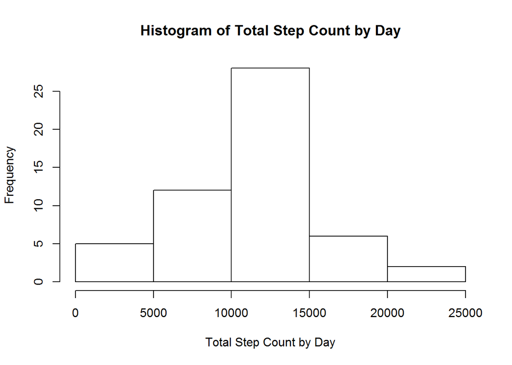

```r
hist(total_step_count_by_date$Total_Step_Count, main="Histogram of Total Step Count by Day",
     xlab="Total Step Count by Day")
```